# Project 5

LetsPlayUnoR3

2023-10-09

## Introduction

This project aims to explore the impact of physical activity on human body temperature. A previous study conducted found that increased physical activity can lead to elevated body temperature due to metabolic changes. This project seeks to replicate and extend these findings by collecting and analyzing temperature data using Arduino-based sensors. The investigation will involve comparing body temperature during periods of rest and exercise, with the expectation that the results will help our understanding of how exercise affect human physiology.(Neves 2015)

## Methods

In order to measure temperature of individuals, a **DS18B20 Temperature Sensor** was used. This sensor was wired through an *Arduino UNO* unit to interface with the data collection software, Arduino IDE.

The resting state was measured once each individual had been sedentary for 10 minutes. Then, the active state was measured after each individual had done 5 minutes of jumping jacks. Each temperature measurement period lasted 100 seconds.

## Results

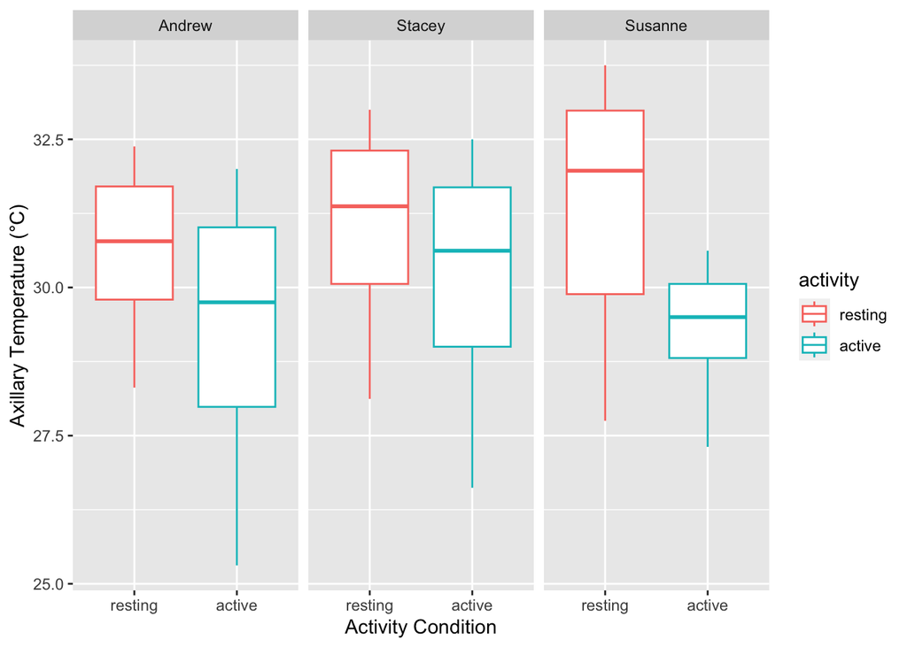

The figure above shows that the data for the active status of physical activity had an overall lower range of temperatures than the resting status data. Susanne had the greatest decrease in temperature after physical activity, while Stacey and Andrew experienced a less significant drop of temperature.

## Conclusion

In the article, Kenny explains that there’s a restoration of thermoregulation post-exercise by returning to the body’s normal core temperature as time goes on. The body is triggered to increase heat loss during recovery, as indicated by our data collected before and after conducting physical activity. The combination of losing heat and still having residual heat from the temperature spike led to the general trend of decreased active temperature.(Kenny 2017)

## Author’s Contribution

- Susanne found the introduction study and provided explanation connecting to our experiment.
- Andrew was able to collect the data and convert it into an appropriate figure via code in Rmd
- Stacey explained the results indicated on the figure and included the conclusion study/its explanation.

## References

Kenny, McGinn, G. P. 2017. “Restoration of Thermoregulation After Exercise.” *Journal of Applied Physiology*.

Neves, Eduardo B. 2015. “Different Responses of the Skin Temperature to Physical Exercise: Systematic Review.” *IEEE*.